# Table of Content

### `rating_numerator` Up(content list)

Many invalid entries: 1776, 960, ...Values higher than 20 are not acceptable.A number of tweets are not about dogs

```python
df_twitter_archive_clean.rating_numerator.value_counts()
```

```
12      558
11      464
10      461
13      351
9       158
8       102
7        55
14       54
5        37
6        32
3        19
4        17
1         9
2         9
420       2
```

[output cut: 26 more lines]

> **Given the strange entries such as 1776, 420,... in the next step ratings are extracted from tweet content so as to investigate the issue**

```python
for i in df_twitter_archive_clean.index:
    try:
        new_rating_numerator = re.search(r'(\d+(\.\d*)?)(?:/\d*)',df_twitter_archive_clean.loc[i,'text']).group(1)
        df_twitter_archive_clean.loc[i,'new_rating_numerator']= new_rating_numerator
    except Exception as e:
        print(str(e))
        df_twitter_archive_clean.loc[i,'new_rating_numerator']= 'no rating'
```

```python
for i in df_twitter_archive_clean.index:
    new_rating = df_twitter_archive_clean.loc[i,'new_rating_numerator']
    old_rating = str(df_twitter_archive_clean.loc[i,'rating_numerator'])
    if (old_rating != new_rating):
        print('Old Rating:',old_rating, 'New Rating:',new_rating)
        print('Tweet Content:', df_twitter_archive_clean.loc[i,'text'])
        ans = input('Do you want to change the entry for rating_numerator? y/n')
        if ans == 'y':
            rn = input('Enter new rating numerator:')
            df_twitter_archive_clean.loc[i,'rating_numerator'] = rn
            df_twitter_archive_clean.loc[i,'new_rating_numerator'] = rn
```

```
Old Rating: 5 New Rating: 13.5
Tweet Content: This is Bella. She hopes her smile made you smile. If not, she is also offering you her favorite monkey. 13.5/10 https://t.co/qjrljjt948
Do you want to change the entry for rating_numerator? y/nn
Old Rating: 75 New Rating: 9.75
Tweet Content: RT @dog_rates: This is Logan, the Chow who lived. He solemnly swears he's up to lots of good. H*ckin magical af 9.75/10 https://t.co/yBO5wu…
Do you want to change the entry for rating_numerator? y/nn
Old Rating: 7 New Rating: 007
Tweet Content: I was going to do 007/10, but the joke wasn't worth the &lt;10 rating
Do you want to change the entry for rating_numerator? y/ny
Enter new rating numerator:7
Old Rating: 75 New Rating: 9.75
Tweet Content: This is Logan, the Chow who lived. He solemnly swears he's up to lots of good. H*ckin magical af 9.75/10 https://t.co/yBO5wuqaPS
Do you want to change the entry for rating_numerator? y/nn
Old Rating: 27 New Rating: 11.27
Tweet Content: This is Sophie. She's a Jubilant Bush Pupper. Super h*ckin rare. Appears at random just to smile at the locals. 11.27/10 would smile back https://t.co/QFaUiIHxHq
Do you want to change the entry for rating_numerator? y/nn
Old Rating: 5 New Rating: 9.5
Tweet Content: I've been told there's a slight possibility he's checking his mirror. We'll bump to 9.5/10. Still a menace
Do you want to change the entry for rating_numerator? y/nn
Old Rating: 26 New Rating: 11.26
Tweet Content: Here we have uncovered an entire battalion of holiday puppers. Average of 11.26/10 https://t.co/eNm2S6p9BD
Do you want to change the entry for rating_numerator? y/nn
```

```python
df_twitter_archive_clean.new_rating_numerator.value_counts()
```

```
12       558
11       464
10       461
13       351
9        158
8        102
7         55
14        54
5         35
6         32
3         19
4         17
2          9
1          9
0          2
```

[output cut: 28 more lines]

> **few entries were fixed. However there are still few more with un-acceptable values. Given that the number of such antries are not very high, tweet content will be checked for further understanding. Invalid ratings will be replaced with 0. And in case it's not a dog, will be labeld accordingly**

```python
df_twitter_archive_clean.new_rating_numerator = df_twitter_archive_clean.new_rating_numerator.astype(float)
list_index_numerator = df_twitter_archive_clean[df_twitter_archive_clean.new_rating_numerator>20].index
for i in list_index_numerator:
    numerator = df_twitter_archive_clean.loc[i,'new_rating_numerator']
    print('Current numerator:',numerator)
    print('\n',df_twitter_archive_clean.loc[i,'text'])
    ans = input ('Do you want to change the numerator entry? y/n')
    if (ans =='y'):
        df_twitter_archive_clean.loc[i,'new_rating_numerator'] = input('Enter the new value:')
```

```
Current numerator: 420.0

 @dhmontgomery We also gave snoop dogg a 420/10 but I think that predated your research
Do you want to change the numerator entry? y/ny
Enter the new value:not a dog
Current numerator: 666.0

 @s8n You tried very hard to portray this good boy as not so good, but you have ultimately failed. His goodness shines through. 666/10
Do you want to change the numerator entry? y/ny
Enter the new value:0
Current numerator: 182.0

 @markhoppus 182/10
Do you want to change the numerator entry? y/ny
Enter the new value:0
Current numerator: 960.0

 @jonnysun @Lin_Manuel ok jomny I know you're excited but 960/00 isn't a valid rating, 13/10 is tho
Do you want to change the numerator entry? y/ny
Enter the new value:13
Current numerator: 84.0

 The floofs have been released I repeat the floofs have been released. 84/70 https://t.co/NIYC820tmd
Do you want to change the numerator entry? y/ny
Enter the new value:12
Current numerator: 24.0

 Meet Sam. She smiles 24/7 &amp; secretly aspires to be a reindeer.
Keep Sam smiling by clicking and sharing this link:
https://t.co/98tB8y7y7t https://t.co/LouL5vdvxx
Do you want to change the numerator entry? y/ny
Enter the new value:0
Current numerator: 165.0

 Why does this never happen at my front door... 165/150 https://t.co/HmwrdfEfUE
Do you want to change the numerator entry? y/ny
Enter the new value:11
Current numerator: 1776.0

 This is Atticus. He's quite simply America af. 1776/10 https://t.co/GRXwMxLBkh
```

[output cut: 51 more lines]

```
 IT'S PUPPERGEDDON. Total of 144/120 ...I think https://t.co/ZanVtAtvIq
Do you want to change the numerator entry? y/ny
Enter the new value:12
Current numerator: 88.0

 Here we have an entire platoon of puppers. Total score: 88/80 would pet all at once https://t.co/y93p6FLvVw
Do you want to change the numerator entry? y/ny
Enter the new value:11
Current numerator: 420.0

 After so many requests... here you go.

Good dogg. 420/10 https://t.co/yfAAo1gdeY
Do you want to change the numerator entry? y/ny
Enter the new value:not a dog
```

```python
df_twitter_archive_clean.new_rating_numerator.value_counts()
```

```
12.0         558
11.0         464
10.0         461
13.0         351
9.0          158
8.0          102
7.0           55
14.0          54
5.0           35
6.0           32
3.0           19
4.0           17
1.0            9
2.0            9
11             7
12             4
0              4
15.0           2
9.75           2
not a dog      2
0.0            2
17.0           1
20.0           1
9              1
13             1
11.27          1
13.5           1
10             1
9.5            1
11.26          1
Name: new_rating_numerator, dtype: int64
```

> **Many of the high values were due to the fact that more than one dog in the picture were rated. For example 10 dogs each rated 12 and the rating was given as 120/10**

### `rating_denominator` Up(content list)

`rating_denominator` All entries should be 10

```python
df_twitter_archive_clean.rating_denominator.value_counts()
```

```
10     2333
11        3
50        3
80        2
20        2
2         1
16        1
40        1
70        1
15        1
90        1
110       1
120       1
130       1
150       1
170       1
7         1
0         1
Name: rating_denominator, dtype: int64
```

```python
df_twitter_archive_clean['rating_denominator']=10
df_twitter_archive_clean.rating_denominator
```

```
0       10
1       10
2       10
3       10
4       10
        ..
2351    10
2352    10
2353    10
2354    10
2355    10
Name: rating_denominator, Length: 2356, dtype: int64
```

```python
df_twitter_archive_clean.drop('rating_numerator',axis = 1,inplace = True)
df_twitter_archive_clean.rename(columns = {'new_rating_numerator':'rating_numerator'}, inplace = True)
df_twitter_archive_clean.to_csv(path_twitter_archive_clean,index = False)
df_twitter_archive_clean = pd.read_csv(path_twitter_archive_clean, dtype = {'tweet_id':'object'})
df_twitter_archive_clean.head(2)
```

|  | tweet_id | in_reply_to_status_id | in_reply_to_user_id | timestamp | source | text | retweeted_status_id | retweeted_status_user_id | retweeted_status_timestamp | expanded_urls | rating_denominator | dog_name | dog_stage | rating_numerator |
| --- | --- | --- | --- | --- | --- | --- | --- | --- | --- | --- | --- | --- | --- | --- |
| 0 | 892420643555336193 | NaN | NaN | 2017-08-01 16:23:56+00:00 | <a href="http://twitter.com/download/iphone" r... | This is Phineas. He's a mystical boy. Only eve... | NaN | NaN | NaN | https://twitter.com/dog_rates/status/892420643... | 10 | Phineas | no entry | 13.0 |
| 1 | 892177421306343426 | NaN | NaN | 2017-08-01 00:17:27+00:00 | <a href="http://twitter.com/download/iphone" r... | This is Tilly. She's just checking pup on you.... | NaN | NaN | NaN | https://twitter.com/dog_rates/status/892177421... | 10 | Tilly | no entry | 13.0 |

### Drop retweets Up(content list)

```python
retweets_index = df_twitter_archive_clean[df_twitter_archive_clean.retweeted_status_id.isna() == False].index
df_twitter_archive_clean.drop(retweets_index, axis = 0, inplace = True)
df_twitter_archive_clean[df_twitter_archive_clean.retweeted_status_id.isna() == False].index
```

### Identify and record tweets that are not about dogs Up(content list)

```python
df_twitter_archive_clean.eq('not a dog').sum()
```

```
tweet_id                       0
in_reply_to_status_id          0
in_reply_to_user_id            0
timestamp                      0
source                         0
text                           0
retweeted_status_id            0
retweeted_status_user_id       0
retweeted_status_timestamp     0
expanded_urls                  0
rating_denominator             0
dog_name                      76
dog_stage                      1
rating_numerator               2
dtype: int64
```

```python
not_dog_index_list = df_twitter_archive_clean[df_twitter_archive_clean.dog_name.eq('not a dog') == True].index
not_dog_index_list=not_dog_index_list.append(df_twitter_archive_clean[df_twitter_archive_clean.dog_stage.eq('not a dog') == True].index)
not_dog_index_list=not_dog_index_list.append(df_twitter_archive_clean[df_twitter_archive_clean.rating_numerator.eq('not a dog') == True].index)
len(not_dog_index_list)
```

```
79
```

```python
not_dog_tweet_id_list = []
for i in not_dog_index_list:
    not_dog_tweet_id_list.append(df_twitter_archive_clean.loc[i, 'tweet_id'])
len(not_dog_tweet_id_list)
```

```
79
```

```python
df_twitter_archive_clean.to_csv(path_twitter_archive_clean,index = False)
df_twitter_archive_clean = pd.read_csv(path_twitter_archive_clean, dtype = {'tweet_id':'object'})
```

### `source` Up(content list)

```python
df_twitter_archive_clean.source.value_counts()
```

[output not shown]

```python
df_twitter_archive_clean['tweet_source'] = df_twitter_archive_clean.source.apply(lambda s: s.strip().split('>',1)[1][:-4].replace('Vine - Make a Scene','Vine'))
```

```python
df_twitter_archive_clean.tweet_source.value_counts()
```

```
Twitter for iPhone    2221
Vine                    91
Twitter Web Client      33
TweetDeck               11
Name: tweet_source, dtype: int64
```

```python
df_twitter_archive_clean.to_csv(path_twitter_archive_clean, index = False)
df_twitter_archive_clean = pd.read_csv(path_twitter_archive_clean, dtype = {'tweet_id':'object'})
```

## Image Prediction Dataset Up(content list)

```python
df_image_predictions = pd.read_csv(path_image_predictions, sep = '\t')
```

```python
df_image_predictions.head(3)
```

|  | tweet_id | jpg_url | img_num | p1 | p1_conf | p1_dog | p2 | p2_conf | p2_dog | p3 | p3_conf | p3_dog |
| --- | --- | --- | --- | --- | --- | --- | --- | --- | --- | --- | --- | --- |
| 0 | 666020888022790149 | https://pbs.twimg.com/media/CT4udn0WwAA0aMy.jpg | 1 | Welsh_springer_spaniel | 0.465074 | True | collie | 0.156665 | True | Shetland_sheepdog | 0.061428 | True |
| 1 | 666029285002620928 | https://pbs.twimg.com/media/CT42GRgUYAA5iDo.jpg | 1 | redbone | 0.506826 | True | miniature_pinscher | 0.074192 | True | Rhodesian_ridgeback | 0.072010 | True |
| 2 | 666033412701032449 | https://pbs.twimg.com/media/CT4521TWwAEvMyu.jpg | 1 | German_shepherd | 0.596461 | True | malinois | 0.138584 | True | bloodhound | 0.116197 | True |

```python
df_image_predictions.info()
```

```
<class 'pandas.core.frame.DataFrame'>
RangeIndex: 2075 entries, 0 to 2074
Data columns (total 12 columns):
 #   Column    Non-Null Count  Dtype
---  ------    --------------  -----
 0   tweet_id  2075 non-null   int64
 1   jpg_url   2075 non-null   object
 2   img_num   2075 non-null   int64
 3   p1        2075 non-null   object
 4   p1_conf   2075 non-null   float64
 5   p1_dog    2075 non-null   bool
 6   p2        2075 non-null   object
 7   p2_conf   2075 non-null   float64
 8   p2_dog    2075 non-null   bool
 9   p3        2075 non-null   object
 10  p3_conf   2075 non-null   float64
 11  p3_dog    2075 non-null   bool
dtypes: bool(3), float64(3), int64(2), object(4)
memory usage: 152.1+ KB
```

```python
df_image_predictions_clean = df_image_predictions.copy()
```

### `tweet_id` Up(content list)

Data type is int. should be string

```python
df_image_predictions_clean.tweet_id = df_image_predictions_clean.tweet_id.astype(str)
```

Image prediction algorithm produces 3 predictions each with a level of certainty that suggests what breed of a dog is in the picture. The breed is stored under columns `p1`, `p2` and `p3`.For better readability the column names are to be changed to `prediction1`,`prediction2` and `prediction3`.  
The level of certainty for each prediction is recorded in columns `p1_conf`, `p2_conf` and`p3_conf`. These names are to be changed to `prediction1_confidence`, `prediction2_confidence` and `prediction3_confidence`.  
There are cases where the prediction(s) suggest it is not a dog. To mark such entries `p1_dog`, `p2_dog`, `p3_dog`hold boolean values (True, False). names are changed to `predict1_is_dog`, `predict2_is_dog` and `predict3_is_dog`.

### Columns `p1`, `p1_conf`, `p2`, `p2_conf`,`p3`, `p3_conf`, `p1_dog`, `p2_dog`, `p3_dog` Up(content list)

Column names are not informative and should change

```python
df_image_predictions_clean.rename(columns = {'p1':'prediction1','p1_conf':'prediction1_confidence','p2':'prediction2','p2_conf':'prediction2_confidence','p3':'prediction3','p3_conf':'prediction3_confidence','p1_dog':'predict1_is_dog','p2_dog':'predict2_is_dog','p3_dog':'predict3_is_dog'}, inplace = True)
```

```python
df_image_predictions_clean[['prediction1_confidence','prediction2_confidence','prediction3_confidence']].describe()
```

|  | prediction1_confidence | prediction2_confidence | prediction3_confidence |
| --- | --- | --- | --- |
| count | 2075.000000 | 2.075000e+03 | 2.075000e+03 |
| mean | 0.594548 | 1.345886e-01 | 6.032417e-02 |
| std | 0.271174 | 1.006657e-01 | 5.090593e-02 |
| min | 0.044333 | 1.011300e-08 | 1.740170e-10 |
| 25% | 0.364412 | 5.388625e-02 | 1.622240e-02 |
| 50% | 0.588230 | 1.181810e-01 | 4.944380e-02 |
| 75% | 0.843855 | 1.955655e-01 | 9.180755e-02 |
| max | 1.000000 | 4.880140e-01 | 2.734190e-01 |

### Entry correctness check for `predict1_is_dog`,`predict2_is_dog`,`predict3_is_dog` Up(content list)

Once the values for all three columns are True, it can be concluded with relatively high certainty(average certainty for prediction 1 is 60%) that it is a dog in the picture. But how can the certainty be maintained in cases where only one of the predictions is True or the first prediction is False and the other two ore True. These scenarios and similar ones should be investigated. Following measures are taken in the coming steps:

- In previous steps where `Twitter Archive Dataset` was cleaned, a number of irrelevant tweets (no dog) were identified. And `tweet_id` of those were stored in a list `not_dog_tweet_id_list`. This comes handy in this step.
- A reliable indicator that assures, the image is of a dog is if there's a name entry for that tweet/row. dog stage and ratings are not as reliable as the data shows people call ducks,kangaroos, fish, etc pupper, daggo,... and rate them as well.
- In cases where there's no name available and uncertainty is high, manual cleaning is performed. Mainly because the number of those rows are not very high.

In the end, it is either a dog or not. Findings are eventually recorded under a new column `is_dog`with **True** and **False** values.

**1. `predict1_is_dog`,`predict2_is_dog`, `predict3_is_dog` are all False**

```python
df_image_predictions_clean[((df_image_predictions_clean.predict1_is_dog == False) & (df_image_predictions_clean.predict2_is_dog == False)& (df_image_predictions_clean.predict3_is_dog == False)) == True].shape[0]
```

```
324
```

> **According to all prediction entries, there are 324 entries that are not dogs.**

Earlier **79** rows were identified from Twitter Archive Dataset that according to tweet content, were not about dogs. Image Prediction Dataset is checked to see if the tweet ID of any of those tweets are present in this dataset.

```python
not_dog_index_list = []
for i in df_image_predictions_clean.index:
    t_id = df_image_predictions_clean.loc[i,'tweet_id']
    if t_id in not_dog_tweet_id_list:
        not_dog_index_list.append(i)
len(not_dog_index_list)
```

```
72
```

Label rows in Image Prediction Dataset that are not dogs

```python
for i in not_dog_index_list:
    df_image_predictions_clean.loc[i,'is_dog'] = False
```

```python
all_false_index_list = df_image_predictions_clean[((df_image_predictions_clean.predict1_is_dog == False) & (df_image_predictions_clean.predict2_is_dog == False)& (df_image_predictions_clean.predict3_is_dog == False)) == True].index
not_dogs_count = 0
for i in all_false_index_list:
    if i in not_dog_index_list:
        not_dogs_count+=1
not_dogs_count
```

```
13
```

> **Number of rows where all three predictions indicate the image doesn't belong to a dog dropped from 324 to 311. This is not significat. Therefore further investigation is needed**

One approach is to look up the corresponding data in Twitter Archive Dataset in order to clarify if the picture belongs to a dog or not. If there's entry for a name, we can conclude that there exists a dog and prediction algorithm has made a mistake.

```python
df_all_false = df_image_predictions_clean[((df_image_predictions_clean.predict1_is_dog == False) & (df_image_predictions_clean.predict2_is_dog == False)& (df_image_predictions_clean.predict3_is_dog == False)) == True]
df_temp = df_all_false.merge(df_twitter_archive_clean, how = 'inner',left_on = 'tweet_id',right_on = 'tweet_id')
```

```python
df_temp.shape[0]
```

```
324
```

```python
df_temp.dog_name.value_counts()
```

```
no name      140
not a dog     12
Jerry          3
Steven         3
Clarence       2
            ...
Pepe           1
Bobby          1
Dwight         1
Gary           1
Stanley        1
Name: dog_name, Length: 155, dtype: int64
```

> **In 172 cases (known) entries corresponds with a name, it is safe to assume there's a dog in the picture. Therefore, Image Prediction Algorithm has wrongly indicated that the picture is not of a dog.Column `is_dog`entries for these rows will be True.**

```python
for i in df_temp.index:
    twt_id = df_temp.loc[i,'tweet_id']
    twt_index = df_image_predictions_clean[df_image_predictions_clean.tweet_id.eq(twt_id) == True].index.values[0]
    if (df_temp.loc[i,'dog_name'] !='no name'):
        if df_temp.loc[i,'dog_name'] =='not a dog':
            df_temp.drop(i,axis=0,inplace = True)
        else:
            df_image_predictions_clean.loc[twt_index,'is_dog'] = True
            df_temp.drop(i,axis=0,inplace = True)
```

```python
df_temp.shape[0]
```

```
140
```

Since the number of rows with this issue is not that high, manual cleaning is performed. entries for column `is_dog`in image prediction dataset will be True for entries with a dog in picture and False otherwise

```python
for i in df_temp.index:
    twt_id = df_temp.loc[i,'tweet_id']
    twt_index = df_image_predictions_clean[df_image_predictions_clean.tweet_id.eq(twt_id) == True].index.values[0]
    print(df_temp.loc[i,'text'])
    ans = input('Is there a dog? y/n')
    if ans == 'y':
        df_image_predictions_clean.loc[twt_index,'is_dog'] = True
        df_temp.drop(i,axis=0,inplace = True)
    elif ans == 'n':
        #store the tweet_id for non-dog entries
        not_dog_tweet_id_list.append(twt_id)
```

```
Not familiar with this breed. No tail (weird). Only 2 legs. Doesn't bark. Surprisingly quick. Shits eggs. 1/10 https://t.co/Asgdc6kuLX
Is there a dog? y/nn
Very concerned about fellow dog trapped in computer. 10/10 https://t.co/0yxApIikpk
Is there a dog? y/ny
Unique dog here. Very small. Lives in container of Frosted Flakes (?). Short legs. Must be rare 6/10 would still pet https://t.co/XMD9CwjEnM
Is there a dog? y/nn
Unfamiliar with this breed. Ears pointy af. Won't let go of seashell. Won't eat kibble. Not very fast. Bad dog 2/10 https://t.co/EIn5kElY1S
Is there a dog? y/nn
My goodness. Very rare dog here. Large. Tail dangerous. Kinda fat. Only eats leaves. Doesn't come when called 3/10 https://t.co/xYGdBrMS9h
Is there a dog? y/nn
Here we have a Hufflepuff. Loves vest. Eyes wide af. Flaccid tail. Matches carpet. Always a little blurry. 8/10 https://t.co/7JdgVqDnvR
Is there a dog? y/ny
Quite an advanced dog here. Impressively dressed for canine. Has weapon. About to take out trash. 10/10 good dog https://t.co/8uCMwS9CbV
Is there a dog? y/nn
Here we have a neat pup. Very white. Cool shades. Upcoming cruise? Great dog 10/10 https://t.co/LEaviT37v1
Is there a dog? y/nn
Never seen this breed before. Very pointy pup. Hurts when you cuddle. Still cute tho. 10/10 https://t.co/97HuBrVuOx
Is there a dog? y/nn
Exotic dog here. Long neck. Weird paws. Obsessed with bread. Waddles. Flies sometimes (wow!). Very happy dog. 6/10 https://t.co/rqO4I3nf2N
Is there a dog? y/nn
Never seen dog like this. Breathes heavy. Tilts head in a pattern. No bark. Shitty at fetch. Not even cordless. 1/10 https://t.co/i9iSGNn3fx
Is there a dog? y/nn
RT @dogratingrating: Unoriginal idea. Blatant plagiarism. Curious grammar. -5/10 https://t.co/r7XzeQZWzb
Is there a dog? y/nn
What a dog to start the day with. Very calm. Likes to chill by pond. Corkscrews sticking out of head. Obedient. 7/10 https://t.co/0nIxPTDWAZ
Is there a dog? y/nn
Super rare dog. Endangered (?). Thinks it's funny. Mocks everything I say. Colorful af. Has wings (dope). 9/10 https://t.co/BY8nQAMz0x
Is there a dog? y/nn
Neat dog. Lots of spikes. Always in push-up position. Laid a shit ton of eggs earlier. Super stellar pup. 10/10 https://t.co/ODqrL3zXYE
Is there a dog? y/nn
Wow. Armored dog here. Ready for battle. Face looks dangerous. Not very loyal. Lil dog on back havin a blast. 5/10 https://t.co/SyMoWrp368
Is there a dog? y/nn
This dog resembles a baked potato. Bed looks uncomfortable. No tail. Comes with butter tho. 3/10 petting still fun https://t.co/x89NSCEZCq
Is there a dog? y/nn
This lil pup is Oliver. Hops around. Has wings but doesn't fly (lame). Annoying chirp. Won't catch tennis balls 2/10 https://t.co/DnhUw0aBM2
Is there a dog? y/nn
Fun dogs here. Top one clearly an athlete. Bottom one very stable. Not very soft tho. 9/10s would still cuddle both https://t.co/79sHR36NsI
Is there a dog? y/nn
Sneaky dog here. Tuba player has no clue. 10/10 super sneaky https://t.co/jWVwSppaa2
Is there a dog? y/nn
```

[output cut: 234 more lines]

```
Is there a dog? y/nn
RT @basic_vacek_: I love my new mug easy 13/10 @dog_rates https://t.co/0bYtoL7Wwt
Is there a dog? y/nn
RT @eddie_coe98: Thanks @dog_rates completed my laptop. 10/10 would buy again https://t.co/bO0rThDlXI
Is there a dog? y/nn
Here we have an exotic dog. Good at ukulele. Fashionable af. Has two more arms if needed. Is blue. Knows what 'ohana means. 13/10 would pet https://t.co/gEsymGTXCT
Is there a dog? y/nn
Here we have perhaps the wisest dog of all. Above average with light sabers. Immortal as h*ck. 14/10 dog, or dog not, there is no try https://t.co/upRYxG4KbG
Is there a dog? y/nn
RT @tallylott: h*ckin adorable promposal. 13/10 @dog_rates https://t.co/6n8hzNihJ9
Is there a dog? y/nn
Real funny guys. Sending in a pic without a dog in it. Hilarious. We'll rate the rug tho because it's giving off a very good vibe. 11/10 https://t.co/GCD1JccCyi
Is there a dog? y/nn
I've yet to rate a Venezuelan Hover Wiener. This is such an honor. 14/10 paw-inspiring af (IG: roxy.thedoxy) https://t.co/20VrLAA8ba
Is there a dog? y/ny
```

```python
#change value of corresponding entry in column is_dog to False.
for twt_id in not_dog_tweet_id_list:
    twt_index = df_image_predictions_clean[df_image_predictions_clean.tweet_id.eq(twt_id) == True].index
    df_image_predictions_clean.loc[twt_index,'is_dog'] = False
```

```python
df_image_predictions_clean.to_csv(path_image_predictions_clean, index = False)
df_image_predictions_clean = pd.read_csv(path_image_predictions_clean, dtype = {'tweet_id':'object'})
df_image_predictions_clean.is_dog.value_counts()
```

```
True     231
False    152
Name: is_dog, dtype: int64
```

**2. `predict1_is_dog`,`predict2_is_dog`are False `predict3_is_dog` is True**

Given the fact that the third prediction is the weakest, there's a chance that the algorithm has mistakes in identifying if the image is of a dog or not.

```python
df_image_predictions_clean[((df_image_predictions_clean.predict1_is_dog == False) & (df_image_predictions_clean.predict2_is_dog == False)& (df_image_predictions_clean.predict3_is_dog == True)) == True].shape[0]
```

```
64
```

```python
df_p1p2_false = df_image_predictions_clean[((df_image_predictions_clean.predict1_is_dog == False) & (df_image_predictions_clean.predict2_is_dog == False)& (df_image_predictions_clean.predict3_is_dog == True)) == True]
df_temp = df_p1p2_false.merge(df_twitter_archive_clean, how = 'inner',left_on = 'tweet_id',right_on = 'tweet_id')
df_temp.dog_name.value_counts()
```

```
no name          18
not a dog         3
Happy             2
Albus             1
Mack              1
Geoff             1
Jareld            1
Tango             1
Opal              1
Mookie            1
Kip               1
Bruce             1
Samson            1
Crumpet           1
Lenny             1
Mary              1
Big Jumpy Rat     1
Howie             1
Meera             1
Belle             1
Lipton            1
Jangle            1
Oakley            1
Lucy              1
Indie             1
Kenneth           1
Koko              1
Charles           1
Bailey            1
Zoey              1
Alfie             1
Al                1
Gary              1
Snoop             1
Ralphson          1
Ozzie             1
Lacy              1
Doc               1
Amélie            1
Hazel             1
Winnie            1
Cedrick           1
Milo              1
Gerald            1
Name: dog_name, dtype: int64
```

> **43 rows are definitely dog, 3 are definitely not dogs and 18 should be investigated.**

```python
for i in df_temp.index:
    twt_id = df_temp.loc[i,'tweet_id']
    twt_index = df_image_predictions_clean[df_image_predictions_clean.tweet_id.eq(twt_id) == True].index.values[0]
    if (df_temp.loc[i,'dog_name'] !='no name'):
        if df_temp.loc[i,'dog_name'] =='not a dog':
            df_temp.drop(i,axis=0,inplace = True)
        else:
            df_image_predictions_clean.loc[twt_index,'is_dog'] = True
            df_temp.drop(i,axis=0,inplace = True)
```

```python
for i in df_temp.index:
    twt_id = df_temp.loc[i,'tweet_id']
    twt_index = df_image_predictions_clean[df_image_predictions_clean.tweet_id.eq(twt_id) == True].index.values[0]
    print(df_temp.loc[i,'text'])
    ans = input('Is there a dog? y/n')
    if ans == 'y':
        df_image_predictions_clean.loc[twt_index,'is_dog'] = True
        df_temp.drop(i,axis=0,inplace = True)
    elif ans == 'n':
        #store the tweet_id for non-dog entries
        not_dog_tweet_id_list.append(twt_id)
```

```
My oh my. This is a rare blond Canadian terrier on wheels. Only $8.98. Rather docile. 9/10 very rare https://t.co/yWBqbrzy8O
Is there a dog? y/ny
2 rare dogs. They waddle (v inefficient). Sometimes slide on bellies. Right one wants to be aircraft Marshall. 9/10s https://t.co/P8bivfp5sU
Is there a dog? y/nn
This dog can't see its haters. 11/10 https://t.co/35BcGFdEAK
Is there a dog? y/nn
Neat pup here. Enjoys lettuce. Long af ears. Short lil legs. Hops surprisingly high for dog. 9/10 still very petable https://t.co/HYR611wiA4
Is there a dog? y/nn
Pack of horned dogs here. Very team-oriented bunch. All have weird laughs. Bond between them strong. 8/10 for all https://t.co/U7DQQdZ0mX
Is there a dog? y/nn
*screeches for a sec and then faints* 12/10 https://t.co/N5QL4ySBEx
Is there a dog? y/ny
Watch out Airbud. This pupper is also good at the sports. 12/10 I'm thinking D1 https://t.co/1HrFdo7M0C
Is there a dog? y/ny
IT'S PUPPERGEDDON. Total of 144/120 ...I think https://t.co/ZanVtAtvIq
Is there a dog? y/ny
This dog doesn't know how to stairs. Quite tragic really. 9/10 get it together pup https://t.co/kTpr9PTMg1
Is there a dog? y/ny
Happy Friday here's a sleepy pupper 12/10 https://t.co/eBcqv9SPkY
Is there a dog? y/ny
What hooligan sent in pictures w/out a dog in them? Churlish af. 3/10 just bc that's a neat fluffy bean bag chair https://t.co/wcwoGOkZvz
Is there a dog? y/nn
I swear to god if we get sent another Blue Madagascan Peacock we'll deactivate. We 👏 Only 👏 Rate 👏 Dogs... 9/10 https://t.co/bbta2Q4URK
Is there a dog? y/nn
Guys... Dog Jesus 2.0
13/10 buoyant af https://t.co/CuNA7OwfKQ
Is there a dog? y/ny
This is one of the most reckless puppers I've ever seen. How she got a license in the first place is beyond me. 6/10 https://t.co/z5bAdtn9kd
Is there a dog? y/ny
"Good afternoon class today we're going to learn what makes a good boy so good" 13/10 https://t.co/f1h2Fsalv9
Is there a dog? y/ny
PUPDATE: I'm proud to announce that Toby is 236 days sober. Pupgraded to a 13/10. We're all very proud of you, Toby https://t.co/a5OaJeRl9B
Is there a dog? y/ny
HI. MY. NAME. IS. BOOMER. AND. I. WANT. TO. SAY. IT'S. H*CKIN. RIDICULOUS. THAT. DOGS. CAN'T VOTE. ABSOLUTE. CODSWALLUP. THANK. YOU. 13/10 https://t.co/SqKJPwbQ2g
Is there a dog? y/ny
RT @dog_rates: "Good afternoon class today we're going to learn what makes a good boy so good" 13/10 https://t.co/f1h2Fsalv9
Is there a dog? y/ny
```

```python
#change value of corresponding entry in column is_dog to False.
for twt_id in not_dog_tweet_id_list:
    twt_index = df_image_predictions_clean[df_image_predictions_clean.tweet_id.eq(twt_id) == True].index
    df_image_predictions_clean.loc[twt_index,'is_dog'] = False
```

**3. `predict1_is_dog` is False and`predict2_is_dog`, `predict3_is_dog` are True**

First prediction is the strongest one, however there are cases where prediction1 suggest the image is not of a dog and the other two predictions oppose that. interesting to see if there are any mistakes in the predictions and correct them

```python
df_image_predictions_clean[((df_image_predictions_clean.predict1_is_dog == False) & (df_image_predictions_clean.predict2_is_dog == True)& (df_image_predictions_clean.predict3_is_dog == True)) == True].shape[0]
```

```
101
```

```python
df_p1_false = df_image_predictions_clean[((df_image_predictions_clean.predict1_is_dog == False) & (df_image_predictions_clean.predict2_is_dog == True)& (df_image_predictions_clean.predict3_is_dog == True)) == True]
df_temp = df_p1_false.merge(df_twitter_archive_clean, how = 'inner',left_on = 'tweet_id',right_on = 'tweet_id')
df_temp.dog_name.value_counts()
```

```
no name      28
not a dog     2
Ken           2
Cali          2
Chompsky      2
             ..
DayZ          1
Winston       1
Coops         1
Tessa         1
Trevith       1
Name: dog_name, Length: 69, dtype: int64
```

Majority of predictions are correct. However there are 28 row that should be investigated.

```python
for i in df_temp.index:
    twt_id = df_temp.loc[i,'tweet_id']
    twt_index = df_image_predictions_clean[df_image_predictions_clean.tweet_id.eq(twt_id) == True].index.values[0]
    if (df_temp.loc[i,'dog_name'] !='no name'):
        if df_temp.loc[i,'dog_name'] =='not a dog':
            df_temp.drop(i,axis=0,inplace = True)
        else:
            df_image_predictions_clean.loc[twt_index,'is_dog'] = True
            df_temp.drop(i,axis=0,inplace = True)
```

```python
df_temp.shape
```

```
(28, 26)
```

```python
for i in df_temp.index:
    twt_id = df_temp.loc[i,'tweet_id']
    twt_index = df_image_predictions_clean[df_image_predictions_clean.tweet_id.eq(twt_id) == True].index.values[0]
    print(df_temp.loc[i,'text'])
    ans = input('Is there a dog? y/n')
    if ans == 'y':
        df_image_predictions_clean.loc[twt_index,'is_dog'] = True
        df_temp.drop(i,axis=0,inplace = True)
    elif ans == 'n':
        #store the tweet_id for non-dog entries
        not_dog_tweet_id_list.append(twt_id)
```

```
This is an extremely rare horned Parthenon. Not amused. Wears shoes. Overall very nice. 9/10 would pet aggressively https://t.co/QpRjllzWAL
Is there a dog? y/ny
RT @dogratingrating: Exceptional talent. Original humor. Cutting edge, Nova Scotian comedian. 12/10 https://t.co/uarnTjBeVA
Is there a dog? y/ny
Two gorgeous pups here. Both have cute fake horns(adorable). Barn in the back looks on fire. 5/10 would pet rly well https://t.co/w5oYFXi0uh
Is there a dog? y/nn
😂😂😂 10/10 for the dog and the owner https://t.co/5iYF0Ci0EK
Is there a dog? y/ny
Two unbelievably athletic dogs here. Great form. Perfect execution. 10/10 for both https://t.co/sQuKwSKtDE
Is there a dog? y/ny
Extraordinary dog here. Looks large. Just a head. No body. Rather intrusive. 5/10 would still pet https://t.co/ufHWUFA9Pu
Is there a dog? y/nn
When you see sophomores in high school driving. 11/10 https://t.co/m6aC8d1Kzp
Is there a dog? y/ny
Everyone needs to watch this. 13/10 https://t.co/Bb3xnpsWBC
Is there a dog? y/ny
This pupper is very passionate about Christmas. Wanted to give the tree a hug. So cute. 8/10 https://t.co/NsGyECJuq7
Is there a dog? y/ny
This is the saddest/sweetest/best picture I've been sent. 12/10 😢🐶 https://t.co/vQ2Lw1BLBF
Is there a dog? y/ny
Reckless pupper here. Not even looking at road. Absolute menace. No regard for fellow pupper lives. 10/10 still cute https://t.co/96IBkOYB7j
Is there a dog? y/ny
This made my day. 12/10 please enjoy https://t.co/VRTbo3aAcm
Is there a dog? y/ny
"Hello yes I'll just get one of each color thanks" 12/10 for all https://t.co/AMDsllQs7a
Is there a dog? y/ny
"You got any games on your phone" 7/10 for invasive brown Dalmatian pupper https://t.co/yzGR9xjE9Q
Is there a dog? y/nn
Here we see 33 dogs posing for a picture. All get 11/10 for superb cooperation https://t.co/TRAri5iHzd
Is there a dog? y/ny
If a pupper gave that to me I'd probably start shaking and faint from all the joy. 11/10 https://t.co/o9aJVPB25n
Is there a dog? y/ny
This pupper killed this great white in an epic sea battle. Now wears it as a trophy. Such brave. Much fierce. 13/10 https://t.co/Lu0ECu5tO5
Is there a dog? y/ny
Seriously, add us 🐶 11/10 for sad wet pupper https://t.co/xwPE9faVZR
Is there a dog? y/ny
I want to hear the joke this dog was just told. 10/10 https://t.co/1KiuZqqOD4
Is there a dog? y/ny
This is all I want in my life. 12/10 for super sleepy pupper https://t.co/4RlLA5ObMh
Is there a dog? y/ny
RT @dog_rates: Everyone needs to watch this. 13/10 https://t.co/Bb3xnpsWBC
Is there a dog? y/ny
Hopefully this puppo on a swing will help get you through your Monday. 11/10 would push https://t.co/G54yClasz2
Is there a dog? y/ny
Hooman used Pokeball
*wiggle*
*wiggle*
Doggo broke free
10/10 https://t.co/bWSgqnwSHr
Is there a dog? y/ny
She walks herself up and down the train to be petted by all the passengers. 13/10 I can't handle this https://t.co/gwKCspY8N2
Is there a dog? y/ny
Teagan reads entire books in store so they're free. Loved 50 Shades of Grey (how dare I make that joke so late) 9/10 https://t.co/l46jwv5WYv
Is there a dog? y/ny
Here's a pupper in a onesie. Quite pupset about it. Currently plotting revenge. 12/10 would rescue https://t.co/xQfrbNK3HD
Is there a dog? y/ny
When you're so blinded by your systematic plagiarism that you forget what day it is. 0/10 https://t.co/YbEJPkg4Ag
Is there a dog? y/ny
Here we have some incredible doggos for #K9VeteransDay. All brave as h*ck. Salute your dog in solidarity. 14/10 for all https://t.co/SVNMdFqKDL
Is there a dog? y/ny
```

```python
#change value of corresponding entry in column is_dog to False.
for twt_id in not_dog_tweet_id_list:
    twt_index = df_image_predictions_clean[df_image_predictions_clean.tweet_id.eq(twt_id) == True].index
    df_image_predictions_clean.loc[twt_index,'is_dog'] = False
```

```python
df_image_predictions_clean.shape
```

```
(2075, 13)
```

```python
df_image_predictions_clean.is_dog.value_counts()
```

```
True     382
False    161
Name: is_dog, dtype: int64
```

At this point it is safe to assume that the entries that didn't have a dog in the picture are taken out. Therefore, `is_dog`value for the remained row will be determined as follows

```python
index = df_image_predictions_clean[df_image_predictions_clean.is_dog.isna()==True].index
for i in index:
    df_image_predictions_clean.loc[i,'is_dog']= df_image_predictions_clean.loc[i,'predict1_is_dog']|df_image_predictions_clean.loc[i,'predict2_is_dog']|df_image_predictions_clean.loc[i,'predict3_is_dog']
```

```python
df_image_predictions_clean.is_dog.value_counts()
```

```
True     1914
False     161
Name: is_dog, dtype: int64
```

```python
df_image_predictions_clean.to_csv(path_image_predictions_clean, index = False)
df_twitter_archive_clean.to_csv(path_twitter_archive_clean, index = False)
df_image_predictions_clean = pd.read_csv(path_image_predictions_clean, dtype = {'tweet_id':'object'})
df_twitter_archive_clean = pd.read_csv(path_twitter_archive_clean, dtype = {'tweet_id':'object'})
```

### Edit breed names in columns `prediction1`, `prediction2`, `prediction3` Up(content list)

```python
df_image_predictions_clean.prediction1 = df_image_predictions_clean.prediction1.apply(lambda s : s.strip().replace('_',' ').title())
df_image_predictions_clean.prediction2 = df_image_predictions_clean.prediction2.apply(lambda s : s.strip().replace('_',' ').title())
df_image_predictions_clean.prediction3 = df_image_predictions_clean.prediction3.apply(lambda s : s.strip().replace('_',' ').title())
```

```python
df_image_predictions_clean.to_csv(path_image_predictions_clean, index = False)
df_image_predictions_clean = pd.read_csv(path_image_predictions_clean, dtype = {'tweet_id':'object'})
```

### Drop irrelevant columns Up(content list)

```python
df_twitter_archive_clean_temp = df_twitter_archive_clean[['tweet_id', 'timestamp',
       'text', 'expanded_urls', 'rating_denominator',
       'dog_name', 'dog_stage', 'rating_numerator', 'tweet_source']]
df_twitter_archive_clean = df_twitter_archive_clean_temp
```

```python
df_twitter_archive_clean.shape[0]
```

```
2181
```

### Drop irrelevant tweets- not dogs Up(content list)

```python
not_dog_index_list = []
for i in df_twitter_archive_clean.index:
    if df_twitter_archive_clean.loc[i,'tweet_id'] in not_dog_tweet_id_list:
        not_dog_index_list.append(i)
len(not_dog_index_list)
```

```
152
```

```python
df_twitter_archive_clean_temp = df_twitter_archive_clean.copy()
df_twitter_archive_clean_temp.drop(not_dog_index_list, axis = 0, inplace = True)
df_twitter_archive_clean_temp.shape[0]
```

```
2029
```

```python
df_twitter_archive_clean_temp.eq('not a dog').sum()
```

```
tweet_id              0
timestamp             0
text                  0
expanded_urls         0
rating_denominator    0
dog_name              0
dog_stage             0
rating_numerator      0
tweet_source          0
dtype: int64
```

```python
df_twitter_archive_clean = df_twitter_archive_clean_temp.copy()
df_twitter_archive_clean.to_csv(path_twitter_archive_clean, index = False)
```

## Twitter API Dataset Up(content list)

### column `id_str` Up(content list)

```python
df_twitter_api_clean = df_twitter_api.copy()
df_twitter_api_clean.id_str = df_twitter_api_clean.id_str.astype(str)
df_twitter_api_clean.id_str.sample(5)
```

```
1497    690690673629138944
1209    712809025985978368
514     808106460588765185
1705    679854723806179328
1713    679527802031484928
Name: id_str, dtype: object
```

```python
df_twitter_api_clean.rename(columns = {'id_str':'tweet_id'},inplace = True)
```

```python
df_twitter_api_clean.tweet_id.isna().sum()
```

```
0
```

```python
df_twitter_api_clean.tweet_id.duplicated().sum()
```

```
0
```

```python
df_twitter_api_clean.info()
```

```
<class 'pandas.core.frame.DataFrame'>
RangeIndex: 2331 entries, 0 to 2330
Data columns (total 3 columns):
 #   Column          Non-Null Count  Dtype
---  ------          --------------  -----
 0   tweet_id        2331 non-null   object
 1   retweet_count   2331 non-null   int64
 2   favorite_count  2331 non-null   int64
dtypes: int64(2), object(1)
memory usage: 54.8+ KB
```

```python
path_twitter_api_clean = '../../Datasets/twitter_api_clean.csv'
df_twitter_api_clean.to_csv(path_twitter_api_clean, index= False)
```

## Create New Datasets Up(content list)

### Twitter Archive Master Dataset Up(content list)

```python
df_twitter_archive_clean = pd.read_csv(path_twitter_archive_clean, dtype = {'tweet_id':'object'})
df_image_predictions_clean = pd.read_csv(path_image_predictions_clean, dtype = {'tweet_id':'object'})
df_twitter_api_clean = pd.read_csv(path_twitter_api_clean, dtype = {'tweet_id':'object'})
```

```python
df1 = df_twitter_archive_clean.merge(df_twitter_api_clean,how = 'inner', left_on = 'tweet_id', right_on = 'tweet_id')
df_twitter_archive_master = df1.merge(df_image_predictions_clean,how = 'inner', left_on = 'tweet_id', right_on = 'tweet_id')
df_twitter_archive_master.head()
```

|  | tweet_id | timestamp | text | expanded_urls | rating_denominator | dog_name | dog_stage | rating_numerator | tweet_source | retweet_count | ... | prediction1 | prediction1_confidence | predict1_is_dog | prediction2 | prediction2_confidence | predict2_is_dog | prediction3 | prediction3_confidence | predict3_is_dog | is_dog |
| --- | --- | --- | --- | --- | --- | --- | --- | --- | --- | --- | --- | --- | --- | --- | --- | --- | --- | --- | --- | --- | --- |
| 0 | 808106460588765185 | 2016-12-12 00:29:28+00:00 | Here we have Burke (pupper) and Dexter (doggo)... | https://twitter.com/dog_rates/status/808106460... | 10 | no name | doggo | 12.0 | Twitter for iPhone | 2265 | ... | Golden Retriever | 0.426183 | True | Labrador Retriever | 0.257447 | True | Great Pyrenees | 0.126482 | True | True |
| 1 | 808106460588765185 | 2016-12-12 00:29:28+00:00 | Here we have Burke (pupper) and Dexter (doggo)... | https://twitter.com/dog_rates/status/808106460... | 10 | no name | pupper | 12.0 | Twitter for iPhone | 2265 | ... | Golden Retriever | 0.426183 | True | Labrador Retriever | 0.257447 | True | Great Pyrenees | 0.126482 | True | True |
| 2 | 802265048156610565 | 2016-11-25 21:37:47+00:00 | Like doggo, like pupper version 2. Both 11/10 ... | https://twitter.com/dog_rates/status/802265048... | 10 | no name | doggo | 11.0 | Twitter for iPhone | 1415 | ... | Labrador Retriever | 0.897162 | True | Beagle | 0.016895 | True | Rhodesian Ridgeback | 0.012061 | True | True |
| 3 | 802265048156610565 | 2016-11-25 21:37:47+00:00 | Like doggo, like pupper version 2. Both 11/10 ... | https://twitter.com/dog_rates/status/802265048... | 10 | no name | pupper | 11.0 | Twitter for iPhone | 1415 | ... | Labrador Retriever | 0.897162 | True | Beagle | 0.016895 | True | Rhodesian Ridgeback | 0.012061 | True | True |
| 4 | 759793422261743616 | 2016-07-31 16:50:42+00:00 | Meet Maggie &amp; Lila. Maggie is the doggo, L... | https://twitter.com/dog_rates/status/759793422... | 10 | Maggie | doggo | 12.0 | Twitter for iPhone | 1939 | ... | Golden Retriever | 0.985876 | True | Labrador Retriever | 0.001948 | True | Kuvasz | 0.001752 | True | True |

5 rows × 23 columns

```python
df_twitter_archive_master.info()
```

```
<class 'pandas.core.frame.DataFrame'>
Int64Index: 1842 entries, 0 to 1841
Data columns (total 23 columns):
 #   Column                  Non-Null Count  Dtype
---  ------                  --------------  -----
 0   tweet_id                1842 non-null   object
 1   timestamp               1842 non-null   object
 2   text                    1842 non-null   object
 3   expanded_urls           1842 non-null   object
 4   rating_denominator      1842 non-null   int64
 5   dog_name                1842 non-null   object
 6   dog_stage               1842 non-null   object
 7   rating_numerator        1842 non-null   float64
 8   tweet_source            1842 non-null   object
 9   retweet_count           1842 non-null   int64
 10  favorite_count          1842 non-null   int64
 11  jpg_url                 1842 non-null   object
 12  img_num                 1842 non-null   int64
 13  prediction1             1842 non-null   object
 14  prediction1_confidence  1842 non-null   float64
 15  predict1_is_dog         1842 non-null   bool
 16  prediction2             1842 non-null   object
 17  prediction2_confidence  1842 non-null   float64
 18  predict2_is_dog         1842 non-null   bool
 19  prediction3             1842 non-null   object
 20  prediction3_confidence  1842 non-null   float64
 21  predict3_is_dog         1842 non-null   bool
 22  is_dog                  1842 non-null   bool
dtypes: bool(4), float64(4), int64(4), object(11)
memory usage: 295.0+ KB
```

### `dog_breed` Up(content list)

In this step once again cleaning is performed to weed out the entries without a dog in the picture. And settle dow for a breed for each entry. To do so numerical values are opted for `predict1_is_dog`, `predict2_is_dog`, `predict3_is_dog`

```python
#using numerical value for prediction instead of boolean
prediction_list = ['predict1_is_dog', 'predict2_is_dog', 'predict3_is_dog']
for p in prediction_list:
    df_twitter_archive_master[p] = df_twitter_archive_master[p].astype(int)
```

```python
df_twitter_archive_master.prediction1_confidence = df_twitter_archive_master.prediction1_confidence.apply(lambda p: round(p,3))
df_twitter_archive_master.prediction2_confidence = df_twitter_archive_master.prediction2_confidence.apply(lambda p: round(p,3))
df_twitter_archive_master.prediction3_confidence = df_twitter_archive_master.prediction3_confidence.apply(lambda p: round(p,3))
```

```python
df_twitter_archive_master.dog_name = df_twitter_archive_master.dog_name.apply(lambda n: n.strip().title())
df_twitter_archive_master.dog_stage = df_twitter_archive_master.dog_stage.apply(lambda n: n.strip().title())
df_twitter_archive_master.dog_stage = df_twitter_archive_master.dog_stage.apply(lambda n: n.strip().title())
df_twitter_archive_master['is_dog2'] = df_twitter_archive_master['predict1_is_dog'] +df_twitter_archive_master['predict2_is_dog']+df_twitter_archive_master['predict3_is_dog']
df_twitter_archive_master.head(2)
```

|  | tweet_id | timestamp | text | expanded_urls | rating_denominator | dog_name | dog_stage | rating_numerator | tweet_source | retweet_count | ... | prediction1_confidence | predict1_is_dog | prediction2 | prediction2_confidence | predict2_is_dog | prediction3 | prediction3_confidence | predict3_is_dog | is_dog | is_dog2 |
| --- | --- | --- | --- | --- | --- | --- | --- | --- | --- | --- | --- | --- | --- | --- | --- | --- | --- | --- | --- | --- | --- |
| 0 | 808106460588765185 | 2016-12-12 00:29:28+00:00 | Here we have Burke (pupper) and Dexter (doggo)... | https://twitter.com/dog_rates/status/808106460... | 10 | No Name | Doggo | 12.0 | Twitter for iPhone | 2265 | ... | 0.426 | 1 | Labrador Retriever | 0.257 | 1 | Great Pyrenees | 0.126 | 1 | True | 3 |
| 1 | 808106460588765185 | 2016-12-12 00:29:28+00:00 | Here we have Burke (pupper) and Dexter (doggo)... | https://twitter.com/dog_rates/status/808106460... | 10 | No Name | Pupper | 12.0 | Twitter for iPhone | 2265 | ... | 0.426 | 1 | Labrador Retriever | 0.257 | 1 | Great Pyrenees | 0.126 | 1 | True | 3 |

2 rows × 24 columns

```python
df_twitter_archive_master.is_dog2.value_counts().sort_values()
```

```
1     144
0     224
2     312
3    1162
Name: is_dog2, dtype: int64
```

```python
#Number of Rows where it's definitely a dog but only one prediction suggests as such
df_twitter_archive_master[((df_twitter_archive_master.is_dog == True) & (df_twitter_archive_master.is_dog2 == 1))== True ].shape[0]
```

```
144
```

```python
df_twitter_archive_master[((df_twitter_archive_master.is_dog == True) & (df_twitter_archive_master.is_dog2 == 1))== True ].predict1_is_dog.value_counts()
```

```
0    104
1     40
Name: predict1_is_dog, dtype: int64
```

> **In previous steps cases with following scenarios were considered. And rows were labeld accordingly.**
> - all predictions suggest the image is not that of a dog
> - prediction 1 and 2 suggest the image is not that of a dog. But prediction 3 suggests it is
> - prediction 1 suggests the image is not that of a dog. But prediction 2 and 3 suggests it is
> - prediction 1 suggests it is a dog. But prediction 2 and 3 suggests it is not.

> **Therefore, here it is only necessary to investigate the ones where second prediction is that it's a dog. and one of the other two suggests otherwise**

```python
df_twitter_archive_master[((df_twitter_archive_master.is_dog == True) & (df_twitter_archive_master.is_dog2 == 1))== True ].predict1_is_dog.eq(0).sum()
```

```
104
```

```python
ind_list =df_twitter_archive_master[((df_twitter_archive_master.is_dog == True) & (df_twitter_archive_master.is_dog2 == 1))== True ].predict1_is_dog.eq(0).index
```

```python
for i in ind_list:
    if df_twitter_archive_master.loc[i,'predict2_is_dog'] == 1:
        if df_twitter_archive_master.loc[i,'dog_name'] == 'No Name':
            print(df_twitter_archive_master.loc[i,'text'])
            ans = input('is it a dog? y/n')
            if(ans == 'n'):
                df_twitter_archive_master.loc[i,'is_dog']  =False
                not_dog_tweet_id_list.append(df_twitter_archive_master.loc[i,'tweet_id'])
```

```
Unbelievable... We. Only. Rate. Dogs. Please stop sending in other things like this Blossoming Flop Kangaroo. Thank you... 11/10 https://t.co/EeeErAbso0
is it a dog? y/nn
Here's a doggo fully pupared for a shower. H*ckin exquisite balance. Sneaky tongue slip too. 13/10 https://t.co/UtEVnQ1ZPg
is it a dog? y/ny
I can't tap the screen to make the hearts appear fast enough. 10/10 for the source of all future unproductiveness https://t.co/wOhuABgj6I
is it a dog? y/ny
You need to watch these two doggos argue through a cat door. Both 11/10 https://t.co/qEP31epKEV
is it a dog? y/ny
Here's a heartwarming scene of a single father raising his two pups. Downright awe-inspiring af. 12/10 for everyone https://t.co/hfddJ0OiNR
is it a dog? y/ny
This pupper only appears through the hole of a Funyun. Much like Phineas, this one is also mysterious af. 10/10 https://t.co/SQsEBWxPyG
is it a dog? y/ny
Happy Wednesday here's a pup wearing a beret. 12/10 please enjoy https://t.co/MXedEzSHIf
is it a dog? y/ny
Here we see a nifty leaping pupper. Feet look deadly. Sad that the holidays are over. 9/10 undeniably huggable https://t.co/ny8mnXhGOW
is it a dog? y/nn
All this pupper wanted to do was go skiing. No one told him about the El Niño. Poor pupper. 10/10 maybe next year https://t.co/fTgbq1UBR9
is it a dog? y/ny
We've got ourselves a battle here. Watch out Reggie. 11/10 https://t.co/ALJvbtcwf0
is it a dog? y/ny
This is just impressive I have nothing else to say. 11/10 https://t.co/LquQZiZjJP
is it a dog? y/ny
Two miniature golden retrievers here. Webbed paws. Don't walk very efficiently. Can't catch a tennis ball. 4/10s https://t.co/WzVLdSHJU7
is it a dog? y/nn
Can't do better than this lol. 10/10 for the owner https://t.co/yrqGyMZhW6
is it a dog? y/ny
Oh boy what a pup! Sunglasses take this one to the next level. Weirdly folds front legs. Pretty big. 6/10 https://t.co/yECbFrSArM
is it a dog? y/nn
```

```python
df_twitter_archive_master.is_dog.value_counts()
```

```
True     1838
False       4
Name: is_dog, dtype: int64
```

```python
index_list = df_twitter_archive_master[df_twitter_archive_master['predict1_is_dog'] == 0].index
for i in index_list:
    df_twitter_archive_master.loc[i,'prediction1'] = ''
```

```python
df_twitter_archive_master.prediction1.value_counts()
```

```
                      418
Golden Retriever      140
Labrador Retriever     88
Pembroke               85
Chihuahua              78
                     ...
Japanese Spaniel        1
Groenendael             1
Entlebucher             1
Silky Terrier           1
Scotch Terrier          1
Name: prediction1, Length: 112, dtype: int64
```

```python
index_list = df_twitter_archive_master[df_twitter_archive_master['predict2_is_dog'] == 0].index
for i in index_list:
    df_twitter_archive_master.loc[i,'prediction2'] = ''
```

```python
df_twitter_archive_master.prediction1.value_counts()
```

```
                      418
Golden Retriever      140
Labrador Retriever     88
Pembroke               85
Chihuahua              78
                     ...
Japanese Spaniel        1
Groenendael             1
Entlebucher             1
Silky Terrier           1
Scotch Terrier          1
Name: prediction1, Length: 112, dtype: int64
```

```python
index_list = df_twitter_archive_master[df_twitter_archive_master['predict3_is_dog'] == 0].index
for i in index_list:
    df_twitter_archive_master.loc[i,'prediction3'] = ''
```

```python
df_twitter_archive_master.prediction3.value_counts()
```

```
                      454
Labrador Retriever     75
Chihuahua              54
Golden Retriever       46
Kelpie                 34
                     ...
Standard Schnauzer      1
Sussex Spaniel          1
Kerry Blue Terrier      1
Irish Wolfhound         1
Affenpinscher           1
Name: prediction3, Length: 117, dtype: int64
```

```python
index_list = df_twitter_archive_master[df_twitter_archive_master.is_dog2 == 1].index
for i in index_list:
    df_twitter_archive_master.loc[i,'dog_breed'] = df_twitter_archive_master.loc[i,'prediction1']+df_twitter_archive_master.loc[i,'prediction2']+df_twitter_archive_master.loc[i,'prediction3']
```

```python
index_list = df_twitter_archive_master[df_twitter_archive_master.is_dog2 == 0].index
for i in index_list:
    df_twitter_archive_master.loc[i,'dog_breed'] = 'unrecognizeable'
```

```python
index_list = df_twitter_archive_master[df_twitter_archive_master.is_dog2 == 3].index
for i in index_list:
    df_twitter_archive_master.loc[i,'dog_breed'] = df_twitter_archive_master.loc[i,'prediction1']
```

```python
index_list = df_twitter_archive_master[df_twitter_archive_master.is_dog2 == 2].index
for i in index_list:
    if df_twitter_archive_master.loc[i,'predict1_is_dog'] == 1:
        df_twitter_archive_master.loc[i,'dog_breed'] = df_twitter_archive_master.loc[i,'prediction1']
    elif df_twitter_archive_master.loc[i,'predict2_is_dog'] == 1:
        df_twitter_archive_master.loc[i,'dog_breed'] = df_twitter_archive_master.loc[i,'prediction2']
```

```python
p_list = ['prediction1','prediction2','prediction3']
index_list = df_twitter_archive_master.index
for i in index_list:
    for p in p_list:
        if df_twitter_archive_master.loc[i,p] == '':
            df_twitter_archive_master.loc[i,p] = 'unrecognizeable'
```

### Drop rows that are not dogs from twitter archive master

```python
drop_list = df_twitter_archive_master[df_twitter_archive_master.is_dog.eq(False) == True].index
df_twitter_archive_master.drop(drop_list, axis = 0, inplace = True)
```

### Drop rows that are not dogs from dog_info dataset (newly found)

```python
for i in df_dog_info.index:
    if df_dog_info.loc[i,'tweet_id'] in not_dog_tweet_id_list:
        df_dog_info.drop(i, axis= 0, inplace = True)
```

### Drop rows that are not dogs from tweet_info dataset (newly found)

```python
for i in df_tweet_info.index:
    if df_tweet_info.loc[i,'tweet_id'] in not_dog_tweet_id_list:
        df_tweet_info.drop(i, axis= 0, inplace = True)
```

```python
path_dog_info_dataset = '../../Datasets/dog_info_clean.csv'
path_tweet_info_dataset = '../../Datasets/tweet_info_clean.csv'
path_twitter_archive_master_dataset = '../../Datasets/twitter_archive_master_clean.csv'
df_dog_info.to_csv('../../Datasets/dog_info_clean.csv',index = False)
df_dog_info = pd.read_csv('../../Datasets/dog_info_clean.csv', dtype = {'tweet_id':'object'})
df_tweet_info.to_csv('../../Datasets/tweet_info_clean.csv',index = False)
df_tweet_info = pd.read_csv('../../Datasets/tweet_info_clean.csv', dtype = {'tweet_id':'object'})
df_twitter_archive_master.to_csv('../../Datasets/twitter_archive_master_clean.csv',index = False)
df_twitter_archive_master_clean = pd.read_csv('../../Datasets/twitter_archive_master_clean.csv', dtype = {'tweet_id':'object'})
```

```python
df_twitter_archive_master_clean.info()
```

```
<class 'pandas.core.frame.DataFrame'>
RangeIndex: 1838 entries, 0 to 1837
Data columns (total 25 columns):
 #   Column                  Non-Null Count  Dtype
---  ------                  --------------  -----
 0   tweet_id                1838 non-null   object
 1   timestamp               1838 non-null   object
 2   text                    1838 non-null   object
 3   expanded_urls           1838 non-null   object
 4   rating_denominator      1838 non-null   int64
 5   dog_name                1838 non-null   object
 6   dog_stage               1838 non-null   object
 7   rating_numerator        1838 non-null   float64
 8   tweet_source            1838 non-null   object
 9   retweet_count           1838 non-null   int64
```

[output cut: 17 more lines]

```python
df_twitter_archive_master_clean.columns
```

```
Index(['tweet_id', 'timestamp', 'text', 'expanded_urls', 'rating_denominator',
       'dog_name', 'dog_stage', 'rating_numerator', 'tweet_source',
       'retweet_count', 'favorite_count', 'jpg_url', 'img_num', 'prediction1',
       'prediction1_confidence', 'predict1_is_dog', 'prediction2',
       'prediction2_confidence', 'predict2_is_dog', 'prediction3',
       'prediction3_confidence', 'predict3_is_dog', 'is_dog', 'is_dog2',
       'dog_breed'],
      dtype='object')
```

```python
df_twitter_archive_master_clean.is_dog.value_counts()
```

```
True    1838
Name: is_dog, dtype: int64
```

```python
df_twitter_archive_master_enhanced = df_twitter_archive_master_clean[['tweet_id', 'text', 'expanded_urls', 'rating_denominator',
       'dog_name', 'dog_stage', 'rating_numerator', 'tweet_source',
       'retweet_count', 'favorite_count', 'jpg_url', 'img_num',
       'dog_breed']]
```

```python
path_twitter_archive_master = '../../Datasets/twitter_archive_master.csv'
df_twitter_archive_master_enhanced.to_csv(path_twitter_archive_master, index = False)
```

# Analysis Up(content list)

```python
df_twitter_archive_master = pd.read_csv(path_twitter_archive_master, dtype = {'tweet_id':'object'})
```

## Insight #1: Most favorited dog stage is: Pupper Up(content list)

```python
df_twitter_archive_master.groupby('dog_stage').favorite_count.sum().sort_values()
```

```
dog_stage
Floofer        84830
Puppo         507610
Doggo        1247510
Pupper       1460944
No Entry    12057590
Name: favorite_count, dtype: int64
```

## Insight #2: Majority of tweets are generated using Twitter for iPhone Up(content list)

```python
df_twitter_archive_master.tweet_source.value_counts()
```

```
Twitter for iPhone    1802
Twitter Web Client      26
TweetDeck               10
Name: tweet_source, dtype: int64
```

## Insight #3 Up(content list)

## Most favorited dog breed is: Golden Retriever

## Least favorited dog breed is: Japanese Spaniel

```python
df_twitter_archive_master.groupby('dog_breed').favorite_count.sum().sort_values()
```

```
dog_breed
Japanese Spaniel         1228
Irish Wolfhound          1396
Standard Schnauzer       1853
Groenendael              2115
Brabancon Griffon        2426
                       ...
Chihuahua              687387
Pembroke               943589
Labrador Retriever    1044240
unrecognizeable       1675246
Golden Retriever      1829644
Name: favorite_count, Length: 114, dtype: int64
```

```python
df_twitter_archive_master.groupby('dog_breed').rating_numerator.mean().sort_values()
```

```
dog_breed
Japanese Spaniel                5.000000
Walker Hound                    9.000000
Scotch Terrier                  9.000000
Soft-Coated Wheaten Terrier     9.214286
Tibetan Terrier                 9.250000
                                 ...
Border Terrier                 12.142857
Tibetan Mastiff                12.250000
Briard                         12.333333
Saluki                         12.500000
Bouvier Des Flandres           13.000000
Name: rating_numerator, Length: 114, dtype: float64
```

```python
df_twitter_archive_master_enhanced.groupby('dog_breed').retweet_count.sum().sort_values()
```

```
dog_breed
Japanese Spaniel         396
Groenendael              492
Entlebucher              619
Irish Wolfhound          726
Brabancon Griffon        763
                       ...
Chihuahua             221727
Pembroke              252953
Labrador Retriever    314574
Golden Retriever      536090
unrecognizeable       555741
Name: retweet_count, Length: 114, dtype: int64
```

## Insight #5: Most retweeted image/dog Up(content list)

```python
max_retweet = df_twitter_archive_master.retweet_count.max()
max_tweet= df_twitter_archive_master[df_twitter_archive_master.retweet_count == max_retweet]
max_jpg_url = df_twitter_archive_master[df_twitter_archive_master.retweet_count == max_retweet].jpg_url.values[0]
```

```python
from PIL import Image
from io import BytesIO
```

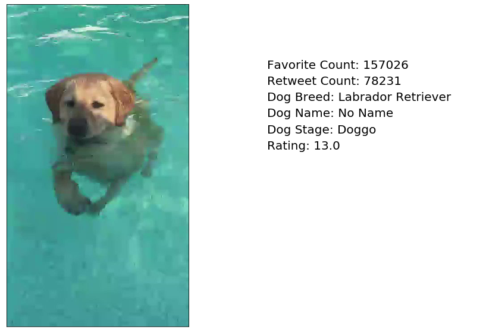

```python
r = requests.get(max_jpg_url)
pil_im = Image.open(BytesIO(r.content))

fig = plt.figure(figsize = (15,10))
ax1 = fig.add_subplot(121)
ax1.imshow(pil_im)
ax1.xaxis.set_visible(False)
ax1.yaxis.set_visible(False)

ax2 = fig.add_subplot(122)
ax2.text(0.05,0.8,'Favorite Count: {} '.format(max_tweet.favorite_count.values[0]), size = 20)
ax2.text(0.05,0.75,'Retweet Count: {} '.format(max_retweet), size = 20)
ax2.text(0.05,0.7,'Dog Breed: {} '.format(max_tweet.dog_breed.values[0]), size = 20)
ax2.text(0.05,0.65,'Dog Name: {} '.format(max_tweet.dog_name.values[0]), size = 20)
ax2.text(0.05,0.6,'Dog Stage: {} '.format(max_tweet.dog_stage.values[0]), size = 20)
ax2.text(0.05,0.55,'Rating: {} '.format(max_tweet.rating_numerator.values[0]), size = 20)

ax2.xaxis.set_visible(False)
ax2.yaxis.set_visible(False)
ax2.axis('off');
```

## Insight #6: Least retweeted image/dog Up(content list)

```python
min_retweet = df_twitter_archive_master.retweet_count.min()
min_tweet= df_twitter_archive_master[df_twitter_archive_master.retweet_count == min_retweet]
min_jpg_url = df_twitter_archive_master[df_twitter_archive_master.retweet_count == min_retweet].jpg_url.values[0]
```

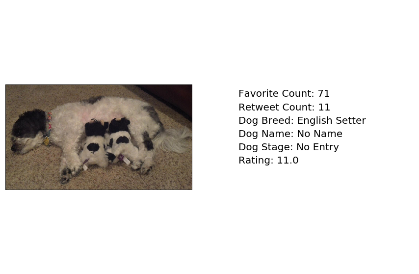

```python
r2 = requests.get(min_jpg_url)
pil_im2 = Image.open(BytesIO(r2.content))

fig2 = plt.figure(figsize = (15,10))
ax3 = fig2.add_subplot(121)
ax3.imshow(pil_im2)
ax3.xaxis.set_visible(False)
ax3.yaxis.set_visible(False)

ax4 = fig2.add_subplot(122)
ax4.text(0.05,0.65,'Favorite Count: {} '.format(min_tweet.favorite_count.values[0]), size = 20)
ax4.text(0.05,0.6,'Retweet Count: {} '.format(min_retweet), size = 20)
ax4.text(0.05,0.55,'Dog Breed: {} '.format(min_tweet.dog_breed.values[0]), size = 20)
ax4.text(0.05,0.5,'Dog Name: {} '.format(min_tweet.dog_name.values[0]), size = 20)
ax4.text(0.05,0.45,'Dog Stage: {} '.format(min_tweet.dog_stage.values[0]), size = 20)
ax4.text(0.05,0.4,'Rating: {} '.format(min_tweet.rating_numerator.values[0]), size = 20)

ax4.xaxis.set_visible(False)
ax4.yaxis.set_visible(False)
ax4.axis('off');
```

# Visualization Up(content list)

```python
import matplotlib.pyplot as plt
import seaborn as sns
%matplotlib inline
```

### Viz#1 Up(content list)

- **How ratings are distributed across the dataset**
- **Relationship between ratings and number of times a tweet is favorited or retweeted**

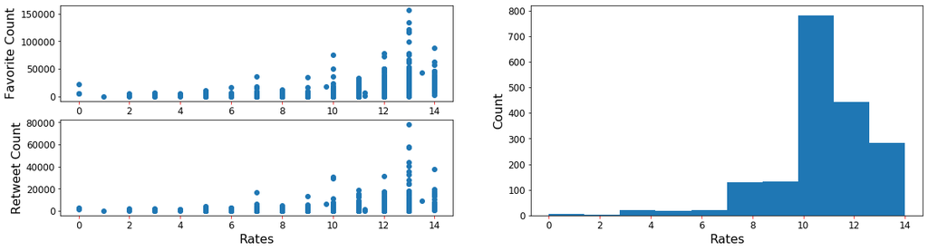

```python
fig = plt.figure( figsize = (20,5))

ax1 = fig.add_subplot(221)
ax1.scatter(df_twitter_archive_master.rating_numerator, df_twitter_archive_master.favorite_count)
ax1.set_ylabel('Favorite Count', size = 16)

ax2 = fig.add_subplot(223)
ax2.scatter(df_twitter_archive_master.rating_numerator, df_twitter_archive_master.retweet_count)
ax2.set_ylabel('Retweet Count', size = 16)
ax2.set_xlabel('Rates', size = 16)

ax3 = fig.add_subplot(122)
ax3.hist(df_twitter_archive_master.rating_numerator)
ax3.set_ylabel('Count', size = 16)
ax3.set_xlabel('Rates', size = 16)


axis_list = [ax1,ax2,ax3]
for ax in axis_list:
    for tick in ax.xaxis.get_ticklabels():
        tick.set_fontsize('large')
        tick.set_color('black')
    for tick in ax.yaxis.get_ticklabels():
        tick.set_fontsize('large')
        tick.set_color('black')
```

### Viz#2: Up(content list)

- **Retweet and Favorite Count distribution across the dataset**
- **Relationship between Retweet and Favorite Count**

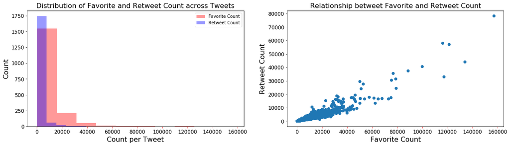

```python
fig = plt.figure(figsize = (20,5))
ax1 = fig.add_subplot(121)
ax1.hist(df_twitter_archive_master.favorite_count, color= 'r', alpha = .4, label = 'Favorite Count')
ax1.hist(df_twitter_archive_master.retweet_count,color= 'b',  alpha = .4, label = 'Retweet Count')
ax1.legend()
ax1.set_xlabel('Count per Tweet', size = 16)
ax1.set_ylabel('Count', size = 16)
ax1.set_title('Distribution of Favorite and Retweet Count across Tweets', size = 16)

ax2 = fig.add_subplot(122)
ax2.scatter(df_twitter_archive_master.favorite_count, df_twitter_archive_master.retweet_count)
ax2.set_xlabel('Favorite Count', size = 16)
ax2.set_ylabel('Retweet Count', size = 16)
ax2.set_title('Relationship betweet Favorite and Retweet Count', size = 16)


axis_list = [ax1,ax2]
for ax in axis_list:
    for tick in ax.xaxis.get_ticklabels():
        tick.set_fontsize('large')
        tick.set_color('black')
    for tick in ax.yaxis.get_ticklabels():
        tick.set_fontsize('large')
        tick.set_color('black')
```